# SN_01_LTD_RECIP_ADDR_L1

Recipient street address line 1 · Text report

## Overview

**Description**

Address Foreign - AddressLine1

**Table**

`SN-P01-T01-LIQUIDATION-TERMINATION-DISSOLUTION` (many)

**Location code**

`SCHED-N-PART-01-LINE-01-COL-F`

**Family**

`SCHED-N-PART-01-LINE-01-COL-F` · siblings: SN_01_LTD_RECIP_ADDR_CITY, SN_01_LTD_RECIP_ADDR_CNTR, SN_01_LTD_RECIP_ADDR_L2, SN_01_LTD_RECIP_ADDR_STATE, SN_01_LTD_RECIP_ADDR_ZIP, SN_01_LTD_RECIP_NAME_ORG_L1

**Data type**

text (xsd: , StreetAddressType)

**Scope**

PZ

**Status**

unreviewed

10

xpaths mapped (6 observed)

30,484

filings with a value

2009–2024

tax years observed

10

open flags (1 errors)

## Flags

| Severity | Flag | Xpath | Detail |
| --- | --- | --- | --- |
| ⚠ error | `COLLISION` | IRS990ScheduleN/LiquidationOfAssetsTableGrp/LiquidationOfAssetsDetail/ForeignAddress/AddressLine1Txt | 70 filings contain 2+ of its xpaths; most common set: /Return/ReturnData/IRS990ScheduleN/LiquidationOfAssetsTableGrp/LiquidationOfAssetsDetail/ForeignAddress/AddressLine1Txt ; /Return/ReturnData/IRS99… |
| ⓘ info | `MANY_NOT_REPEATING` | IRS990ScheduleN/LiquidationOfAssetsTableGrp/LiquidationOfAssetsDetail/USAddress/AddressLine1Txt | many-to-one table, but 66% of values sit in no repeating element |
| ⓘ info | `MANY_NOT_REPEATING` | IRS990ScheduleN/LiquidationTable/LiquidationDetail/AddressUS/AddressLine1 | many-to-one table, but 63% of values sit in no repeating element |
| ⓘ info | `MANY_NOT_REPEATING` | IRS990ScheduleN/LiquidationOfAssetsTableGrp/LiquidationOfAssetsDetail/USAddress/AddressLine1 | many-to-one table, but 61% of values sit in no repeating element |
| ⓘ info | `MANY_NOT_REPEATING` | IRS990ScheduleN/LiquidationOfAssetsTableGrp/LiquidationOfAssetsDetail/ForeignAddress/AddressLine1Txt | many-to-one table, but 60% of values sit in no repeating element |
| ⓘ info | `MANY_NOT_REPEATING` | IRS990ScheduleN/LiquidationTable/LiquidationDetail/AddressForeign/AddressLine1 | many-to-one table, but 57% of values sit in no repeating element |
| ⓘ info | `UNOBSERVED` | IRS990ScheduleN/Form990ScheduleNPartI/LiquidationTable/AddressForeign/AddressLine1 | never observed in TY2009-2024 filings |
| ⓘ info | `UNOBSERVED` | IRS990ScheduleN/Form990ScheduleNPartI/LiquidationTable/AddressUS/AddressLine1 | never observed in TY2009-2024 filings |
| ⓘ info | `UNOBSERVED` | IRS990ScheduleN/LiquidationTable/AddressForeign/AddressLine1 | never observed in TY2009-2024 filings |
| ⓘ info | `UNOBSERVED` | IRS990ScheduleN/LiquidationTable/AddressUS/AddressLine1 | never observed in TY2009-2024 filings |

## Xpaths

All mapped xpaths (under /Return/ReturnData or /Return/ReturnHeader), oldest first. Charts label each series by its xpath.

| Xpath | Form | Chart label | First year | Last year | Versions | Filings | Repeats in |
| --- | --- | --- | --- | --- | --- | --- | --- |
| IRS990ScheduleN/LiquidationTable/LiquidationDetail/AddressUS/AddressLine1 | Sched N | …LiquidationTable/LiquidationDetail/AddressUS/AddressLine1 | 2009 | 2012 | 16 | 2,980 | 36.3% |
| IRS990ScheduleN/LiquidationTable/LiquidationDetail/AddressForeign/AddressLine1 | Sched N | …dationTable/LiquidationDetail/AddressForeign/AddressLine1 | 2010 | 2012 | 7 | 14 | 14.3% |
| IRS990ScheduleN/LiquidationOfAssetsTableGrp/LiquidationOfAssetsDetail/USAddress/AddressLine1 | Sched N | …TableGrp/LiquidationOfAssetsDetail/USAddress/AddressLine1 | 2013 | 2013 | 3 | 1,429 | 37.9% |
| IRS990ScheduleN/LiquidationOfAssetsTableGrp/LiquidationOfAssetsDetail/ForeignAddress/AddressLine1 | Sched N | …Grp/LiquidationOfAssetsDetail/ForeignAddress/AddressLine1 | 2013 | 2013 | 3 | 8 | 25.0% |
| IRS990ScheduleN/LiquidationOfAssetsTableGrp/LiquidationOfAssetsDetail/USAddress/AddressLine1Txt | Sched N | …leGrp/LiquidationOfAssetsDetail/USAddress/AddressLine1Txt | 2014 | 2024 | 34 | 25,817 | 33.7% |
| IRS990ScheduleN/LiquidationOfAssetsTableGrp/LiquidationOfAssetsDetail/ForeignAddress/AddressLine1Txt | Sched N | …/LiquidationOfAssetsDetail/ForeignAddress/AddressLine1Txt | 2014 | 2024 | 29 | 236 | 19.5% |
| IRS990ScheduleN/Form990ScheduleNPartI/LiquidationTable/AddressForeign/AddressLine1 | Sched N | …heduleNPartI/LiquidationTable/AddressForeign/AddressLine1 |  |  |  | 0 |  |
| IRS990ScheduleN/Form990ScheduleNPartI/LiquidationTable/AddressUS/AddressLine1 | Sched N | Other |  |  |  | 0 |  |
| IRS990ScheduleN/LiquidationTable/AddressForeign/AddressLine1 | Sched N | Other |  |  |  | 0 |  |
| IRS990ScheduleN/LiquidationTable/AddressUS/AddressLine1 | Sched N | Other |  |  |  | 0 |  |

## Coverage

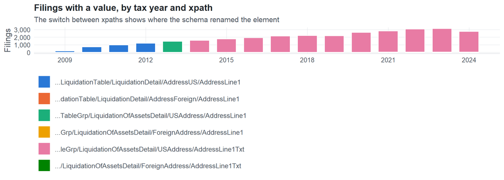

**Table view**

Table view: filings by tax year and series

| Tax year | …LiquidationTable/LiquidationDetail/AddressUS/AddressLine1 | …dationTable/LiquidationDetail/AddressForeign/AddressLine1 | …TableGrp/LiquidationOfAssetsDetail/USAddress/AddressLine1 | …Grp/LiquidationOfAssetsDetail/ForeignAddress/AddressLine1 | …leGrp/LiquidationOfAssetsDetail/USAddress/AddressLine1Txt | …/LiquidationOfAssetsDetail/ForeignAddress/AddressLine1Txt |
| --- | --- | --- | --- | --- | --- | --- |
| 2009 | 164 | 0 | 0 | 0 | 0 | 0 |
| 2010 | 689 | 4 | 0 | 0 | 0 | 0 |
| 2011 | 951 | 4 | 0 | 0 | 0 | 0 |
| 2012 | 1,176 | 6 | 0 | 0 | 0 | 0 |
| 2013 | 0 | 0 | 1,429 | 8 | 0 | 0 |
| 2014 | 0 | 0 | 0 | 0 | 1,557 | 11 |
| 2015 | 0 | 0 | 0 | 0 | 1,751 | 15 |
| 2016 | 0 | 0 | 0 | 0 | 1,886 | 14 |
| 2017 | 0 | 0 | 0 | 0 | 2,128 | 16 |
| 2018 | 0 | 0 | 0 | 0 | 2,180 | 13 |
| 2019 | 0 | 0 | 0 | 0 | 2,153 | 14 |
| 2020 | 0 | 0 | 0 | 0 | 2,601 | 18 |
| 2021 | 0 | 0 | 0 | 0 | 2,764 | 39 |
| 2022 | 0 | 0 | 0 | 0 | 3,011 | 30 |
| 2023 | 0 | 0 | 0 | 0 | 3,096 | 33 |
| 2024 | 0 | 0 | 0 | 0 | 2,690 | 33 |

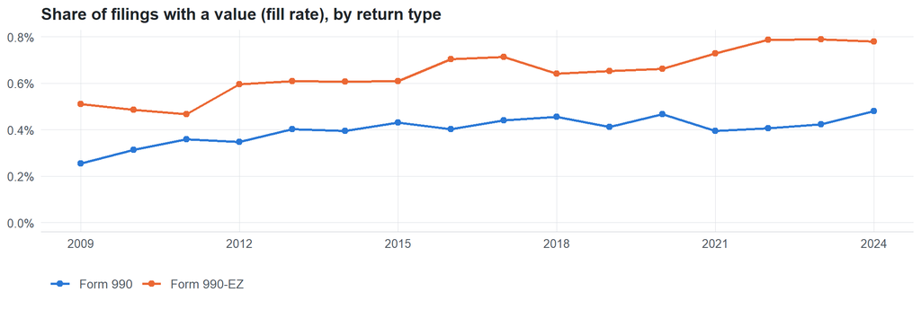

**Table view**

Table view: fill rate

| Tax year | Return type | Filings | All filings | Fill rate |
| --- | --- | --- | --- | --- |
| 2009 | Form 990 | 85 | 33,311 | 0.26% |
| 2009 | Form 990-EZ | 79 | 15,470 | 0.51% |
| 2010 | Form 990 | 386 | 123,025 | 0.31% |
| 2010 | Form 990-EZ | 307 | 63,326 | 0.48% |
| 2011 | Form 990 | 572 | 159,504 | 0.36% |
| 2011 | Form 990-EZ | 383 | 82,048 | 0.47% |
| 2012 | Form 990 | 624 | 179,688 | 0.35% |
| 2012 | Form 990-EZ | 558 | 93,750 | 0.60% |
| 2013 | Form 990 | 801 | 198,855 | 0.40% |
| 2013 | Form 990-EZ | 636 | 104,375 | 0.61% |
| 2014 | Form 990 | 861 | 218,619 | 0.39% |
| 2014 | Form 990-EZ | 707 | 116,417 | 0.61% |
| 2015 | Form 990 | 1,006 | 233,519 | 0.43% |
| 2015 | Form 990-EZ | 760 | 124,894 | 0.61% |
| 2016 | Form 990 | 981 | 243,903 | 0.40% |
| 2016 | Form 990-EZ | 919 | 130,484 | 0.70% |
| 2017 | Form 990 | 1,152 | 261,612 | 0.44% |
| 2017 | Form 990-EZ | 992 | 139,144 | 0.71% |
| 2018 | Form 990 | 1,234 | 271,442 | 0.45% |
| 2018 | Form 990-EZ | 959 | 149,384 | 0.64% |
| 2019 | Form 990 | 1,170 | 283,694 | 0.41% |
| 2019 | Form 990-EZ | 997 | 152,622 | 0.65% |
| 2020 | Form 990 | 1,496 | 320,342 | 0.47% |
| 2020 | Form 990-EZ | 1,123 | 169,864 | 0.66% |
| 2021 | Form 990 | 1,326 | 336,480 | 0.39% |
| 2021 | Form 990-EZ | 1,477 | 202,724 | 0.73% |
| 2022 | Form 990 | 1,420 | 349,055 | 0.41% |
| 2022 | Form 990-EZ | 1,621 | 206,130 | 0.79% |
| 2023 | Form 990 | 1,500 | 354,768 | 0.42% |
| 2023 | Form 990-EZ | 1,629 | 206,379 | 0.79% |
| 2024 | Form 990 | 1,330 | 277,298 | 0.48% |
| 2024 | Form 990-EZ | 1,393 | 178,867 | 0.78% |

## Repeating groups

Table cardinality in the concordance: **many**. 6 of 6 observed xpaths repeat within a filing.

Repeating element each xpath was observed in (from the raw indexed xpath)

| Xpath | Repeating element | Filings (summed over years) |
| --- | --- | --- |
| IRS990ScheduleN/LiquidationTable/LiquidationDetail/AddressUS/AddressLine1 | (none) | 1877 |
| IRS990ScheduleN/LiquidationTable/LiquidationDetail/AddressUS/AddressLine1 | IRS990ScheduleN/LiquidationTable/LiquidationDetail | 1103 |
| IRS990ScheduleN/LiquidationTable/LiquidationDetail/AddressForeign/AddressLine1 | (none) | 8 |
| IRS990ScheduleN/LiquidationTable/LiquidationDetail/AddressForeign/AddressLine1 | IRS990ScheduleN/LiquidationTable/LiquidationDetail | 6 |
| IRS990ScheduleN/LiquidationOfAssetsTableGrp/LiquidationOfAssetsDetail/ForeignAddress/AddressLine1 | (none) | 4 |
| IRS990ScheduleN/LiquidationOfAssetsTableGrp/LiquidationOfAssetsDetail/ForeignAddress/AddressLine1 | IRS990ScheduleN/LiquidationOfAssetsTableGrp/LiquidationOfAssetsDetail | 4 |
| IRS990ScheduleN/LiquidationOfAssetsTableGrp/LiquidationOfAssetsDetail/USAddress/AddressLine1 | (none) | 869 |
| IRS990ScheduleN/LiquidationOfAssetsTableGrp/LiquidationOfAssetsDetail/USAddress/AddressLine1 | IRS990ScheduleN/LiquidationOfAssetsTableGrp/LiquidationOfAssetsDetail | 560 |
| IRS990ScheduleN/LiquidationOfAssetsTableGrp/LiquidationOfAssetsDetail/ForeignAddress/AddressLine1Txt | (none) | 141 |
| IRS990ScheduleN/LiquidationOfAssetsTableGrp/LiquidationOfAssetsDetail/ForeignAddress/AddressLine1Txt | IRS990ScheduleN/LiquidationOfAssetsTableGrp/LiquidationOfAssetsDetail | 95 |
| IRS990ScheduleN/LiquidationOfAssetsTableGrp/LiquidationOfAssetsDetail/USAddress/AddressLine1Txt | (none) | 16933 |
| IRS990ScheduleN/LiquidationOfAssetsTableGrp/LiquidationOfAssetsDetail/USAddress/AddressLine1Txt | IRS990ScheduleN/LiquidationOfAssetsTableGrp/LiquidationOfAssetsDetail | 8884 |

## Values

| Result | Check | Detail |
| --- | --- | --- |
| ✓ pass | Values are text, not numbers | 0% of values are numeric |
| ⓘ info | No sign of truncation | …/LiquidationOfAssetsDetail/ForeignAddress/AddressLine1Txt: longest value is exactly 35 characters; …TableGrp/LiquidationOfAssetsDetail/USAddress/AddressLine1: longest value is exactly 35 characters; … |
| ✓ pass | No dominant boilerplate value | most common value covers 12% of filings: “116 ST AND 85 AVE” |

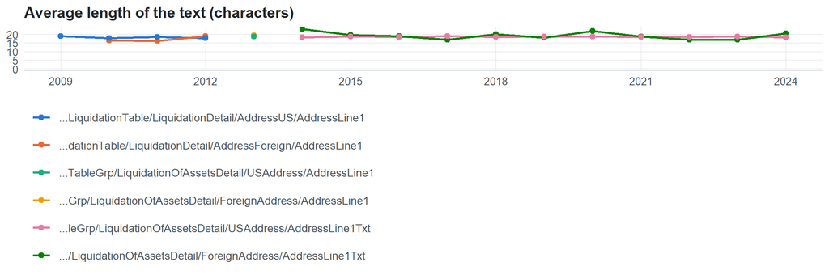

**Table view**

Table view: length and variety by tax year

| Series | Tax year | Filings | Avg length | Max length | Distinct values (approx.) |
| --- | --- | --- | --- | --- | --- |
| …LiquidationTable/LiquidationDetail/AddressUS/AddressLine1 | 2009 | 164 | 19 | 31 | 97 |
| …LiquidationTable/LiquidationDetail/AddressUS/AddressLine1 | 2010 | 689 | 18 | 34 | 250 |
| …LiquidationTable/LiquidationDetail/AddressUS/AddressLine1 | 2011 | 951 | 18 | 35 | 473 |
| …LiquidationTable/LiquidationDetail/AddressUS/AddressLine1 | 2012 | 1,176 | 18 | 35 | 545 |
| …dationTable/LiquidationDetail/AddressForeign/AddressLine1 | 2010 | 4 | 16 | 26 | 1 |
| …dationTable/LiquidationDetail/AddressForeign/AddressLine1 | 2011 | 4 | 16 | 23 | 2 |
| …dationTable/LiquidationDetail/AddressForeign/AddressLine1 | 2012 | 6 | 19 | 35 | 4 |
| …TableGrp/LiquidationOfAssetsDetail/USAddress/AddressLine1 | 2013 | 1,429 | 19 | 35 | 599 |
| …Grp/LiquidationOfAssetsDetail/ForeignAddress/AddressLine1 | 2013 | 8 | 19 | 31 | 3 |
| …leGrp/LiquidationOfAssetsDetail/USAddress/AddressLine1Txt | 2014 | 1,557 | 18 | 35 | 1,286 |
| …leGrp/LiquidationOfAssetsDetail/USAddress/AddressLine1Txt | 2015 | 1,751 | 19 | 35 | 653 |
| …leGrp/LiquidationOfAssetsDetail/USAddress/AddressLine1Txt | 2016 | 1,886 | 18 | 35 | 1,363 |
| …leGrp/LiquidationOfAssetsDetail/USAddress/AddressLine1Txt | 2017 | 2,128 | 19 | 35 | 1,204 |
| …leGrp/LiquidationOfAssetsDetail/USAddress/AddressLine1Txt | 2018 | 2,180 | 18 | 35 | 1,308 |
| …leGrp/LiquidationOfAssetsDetail/USAddress/AddressLine1Txt | 2019 | 2,153 | 19 | 35 | 1,050 |
| …leGrp/LiquidationOfAssetsDetail/USAddress/AddressLine1Txt | 2020 | 2,601 | 19 | 35 | 1,290 |
| …leGrp/LiquidationOfAssetsDetail/USAddress/AddressLine1Txt | 2021 | 2,764 | 18 | 35 | 1,091 |
| …leGrp/LiquidationOfAssetsDetail/USAddress/AddressLine1Txt | 2022 | 3,011 | 18 | 35 | 1,914 |
| …leGrp/LiquidationOfAssetsDetail/USAddress/AddressLine1Txt | 2023 | 3,096 | 19 | 35 | 867 |
| …leGrp/LiquidationOfAssetsDetail/USAddress/AddressLine1Txt | 2024 | 2,690 | 18 | 35 | 1,513 |
| …/LiquidationOfAssetsDetail/ForeignAddress/AddressLine1Txt | 2014 | 11 | 23 | 34 | 7 |
| …/LiquidationOfAssetsDetail/ForeignAddress/AddressLine1Txt | 2015 | 15 | 20 | 33 | 9 |
| …/LiquidationOfAssetsDetail/ForeignAddress/AddressLine1Txt | 2016 | 14 | 19 | 33 | 13 |
| …/LiquidationOfAssetsDetail/ForeignAddress/AddressLine1Txt | 2017 | 16 | 17 | 33 | 4 |
| …/LiquidationOfAssetsDetail/ForeignAddress/AddressLine1Txt | 2018 | 13 | 20 | 33 | 6 |
| …/LiquidationOfAssetsDetail/ForeignAddress/AddressLine1Txt | 2019 | 14 | 18 | 33 | 7 |
| …/LiquidationOfAssetsDetail/ForeignAddress/AddressLine1Txt | 2020 | 18 | 22 | 35 | 16 |
| …/LiquidationOfAssetsDetail/ForeignAddress/AddressLine1Txt | 2021 | 39 | 19 | 35 | 156 |
| …/LiquidationOfAssetsDetail/ForeignAddress/AddressLine1Txt | 2022 | 30 | 17 | 35 | 24 |
| …/LiquidationOfAssetsDetail/ForeignAddress/AddressLine1Txt | 2023 | 33 | 17 | 35 | 13 |
| …/LiquidationOfAssetsDetail/ForeignAddress/AddressLine1Txt | 2024 | 33 | 21 | 35 | 21 |

Most common values by xpath (all years; long values truncated)

| Series | Value | Filings | Share |
| --- | --- | --- | --- |
| …LiquidationTable/LiquidationDetail/AddressUS/AddressLine1 | N/A | 23 | 0.8% |
| …LiquidationTable/LiquidationDetail/AddressUS/AddressLine1 | 66 BROOKS DRIVE | 18 | 0.6% |
| …LiquidationTable/LiquidationDetail/AddressUS/AddressLine1 | 121 STEUART STREET | 17 | 0.6% |
| …LiquidationTable/LiquidationDetail/AddressUS/AddressLine1 | NONE | 16 | 0.5% |
| …LiquidationTable/LiquidationDetail/AddressUS/AddressLine1 | 1401 HAMPTON AVENUE | 14 | 0.5% |
| …LiquidationTable/LiquidationDetail/AddressUS/AddressLine1 | 615 ELSINORE PLACE | 12 | 0.4% |
| …LiquidationTable/LiquidationDetail/AddressUS/AddressLine1 | 250 WILLIAMS STREET | 7 | 0.2% |
| …LiquidationTable/LiquidationDetail/AddressUS/AddressLine1 | 1401 HAMPTON AVE | 6 | 0.2% |
| …LiquidationTable/LiquidationDetail/AddressUS/AddressLine1 | 2290 S ILLINOIS STREET | 6 | 0.2% |
| …LiquidationTable/LiquidationDetail/AddressUS/AddressLine1 | 14587 BARBER AVENUE | 6 | 0.2% |
| …LiquidationTable/LiquidationDetail/AddressUS/AddressLine1 | 1801 RESEARCH BLVD | 5 | 0.2% |
| …LiquidationTable/LiquidationDetail/AddressUS/AddressLine1 | 26 E CHARLOTTE ST | 5 | 0.2% |
| …LiquidationTable/LiquidationDetail/AddressUS/AddressLine1 | 444 W EXCHANGE STREET | 5 | 0.2% |
| …LiquidationTable/LiquidationDetail/AddressUS/AddressLine1 | 100 CHERRY ST SE | 4 | 0.1% |
| …LiquidationTable/LiquidationDetail/AddressUS/AddressLine1 | 250 HOSPITAL DRIVE | 4 | 0.1% |
| …LiquidationTable/LiquidationDetail/AddressUS/AddressLine1 | 3200 Burnet Avenue | 4 | 0.1% |
| …LiquidationTable/LiquidationDetail/AddressUS/AddressLine1 | 36 S STATE STREET SUITE 2200 | 4 | 0.1% |
| …LiquidationTable/LiquidationDetail/AddressUS/AddressLine1 | 5445 S Westridge Drive | 4 | 0.1% |
| …LiquidationTable/LiquidationDetail/AddressUS/AddressLine1 | 310 LENOX AVENUE 2ND FL | 4 | 0.1% |
| …LiquidationTable/LiquidationDetail/AddressUS/AddressLine1 | 501 BATH ROAD | 4 | 0.1% |
| …LiquidationTable/LiquidationDetail/AddressUS/AddressLine1 | PAWTUCKET | 4 | 0.1% |
| …LiquidationTable/LiquidationDetail/AddressUS/AddressLine1 | PO BOX 358 | 4 | 0.1% |
| …LiquidationTable/LiquidationDetail/AddressUS/AddressLine1 | 351 N WILLIAMSON BLVD | 3 | 0.1% |
| …LiquidationTable/LiquidationDetail/AddressUS/AddressLine1 | 4301 ANCHOR PLAZA PARKWAY 360 | 3 | 0.1% |
| …LiquidationTable/LiquidationDetail/AddressUS/AddressLine1 | 2201 EAST 6TH STREET | 3 | 0.1% |
| …LiquidationTable/LiquidationDetail/AddressUS/AddressLine1 | 2290 S ILLINOIS ST | 3 | 0.1% |
| …LiquidationTable/LiquidationDetail/AddressUS/AddressLine1 | 348 W Hospitality | 2 | 0.1% |
| …LiquidationTable/LiquidationDetail/AddressUS/AddressLine1 | 580 MCINTOSH ROAD | 2 | 0.1% |
| …LiquidationTable/LiquidationDetail/AddressUS/AddressLine1 | 1100 LARKSPUR LANDING CIR 340 | 2 | 0.1% |
| …LiquidationTable/LiquidationDetail/AddressUS/AddressLine1 | 115 West Silver Street | 2 | 0.1% |

First rows shown.

## Examples

| Tax year | Return | Xpath | Organization | Value | Source |
| --- | --- | --- | --- | --- | --- |
| 2024 | 990 | IRS990ScheduleN/LiquidationOfAssetsTableGrp/LiquidationOfAssetsDetail/ForeignAddress/AddressLine1Txt | TWG 2021 BIRMINGHAM FOUNDATION | AVE DE LA GARE 12 1003 | [XML](https://gt990datalake-rawdata.s3.amazonaws.com/EfileData/XmlFiles/202510519349301031_public.xml) |
| 2024 | 990EZ | IRS990ScheduleN/LiquidationOfAssetsTableGrp/LiquidationOfAssetsDetail/USAddress/AddressLine1Txt | Pacific Shores Property Owners Assocn | 2445 M Street NW Suite 650 | [XML](https://gt990datalake-rawdata.s3.amazonaws.com/EfileData/XmlFiles/202511329349203641_public.xml) |
| 2023 | 990EZ | IRS990ScheduleN/LiquidationOfAssetsTableGrp/LiquidationOfAssetsDetail/ForeignAddress/AddressLine1Txt | BLANCHARDS ANGUILLA CHILDRENS FUND INC | SOUTH HILL | [XML](https://gt990datalake-rawdata.s3.amazonaws.com/EfileData/XmlFiles/202402149349200345_public.xml) |
| 2023 | 990EZ | IRS990ScheduleN/LiquidationOfAssetsTableGrp/LiquidationOfAssetsDetail/USAddress/AddressLine1Txt | WILDFLOWER COURT | 3260 HOSPITAL DRIVE | [XML](https://gt990datalake-rawdata.s3.amazonaws.com/EfileData/XmlFiles/202412499349200141_public.xml) |
| 2022 | 990EZ | IRS990ScheduleN/LiquidationOfAssetsTableGrp/LiquidationOfAssetsDetail/ForeignAddress/AddressLine1Txt | GHANA COMMUNITY PATHWAYS | KA 48A Tongo Rd | [XML](https://gt990datalake-rawdata.s3.amazonaws.com/EfileData/XmlFiles/202301259349202115_public.xml) |
| 2022 | 990 | IRS990ScheduleN/LiquidationOfAssetsTableGrp/LiquidationOfAssetsDetail/USAddress/AddressLine1Txt | ENERGY CONSUMER CONNECTION INC | N/A | [XML](https://gt990datalake-rawdata.s3.amazonaws.com/EfileData/XmlFiles/202302899349303665_public.xml) |
| 2021 | 990EZ | IRS990ScheduleN/LiquidationOfAssetsTableGrp/LiquidationOfAssetsDetail/ForeignAddress/AddressLine1Txt | THE ICR GLOBAL FOUNDATION | 15 COTSWOLD RD | [XML](https://gt990datalake-rawdata.s3.amazonaws.com/EfileData/XmlFiles/202331669349201133_public.xml) |
| 2021 | 990EZ | IRS990ScheduleN/LiquidationOfAssetsTableGrp/LiquidationOfAssetsDetail/USAddress/AddressLine1Txt | GREATER CINCINNATI GOLF ASSOCIATION | N/A | [XML](https://gt990datalake-rawdata.s3.amazonaws.com/EfileData/XmlFiles/202212359349200321_public.xml) |
| 2020 | 990EZ | IRS990ScheduleN/LiquidationOfAssetsTableGrp/LiquidationOfAssetsDetail/ForeignAddress/AddressLine1Txt | INTERNATIONAL WHEAT GLUTEN ASSOCIATION | AVENUE DES ARTS 43 B-1040 | [XML](https://gt990datalake-rawdata.s3.amazonaws.com/EfileData/XmlFiles/202113419349200511_public.xml) |
| 2020 | 990EZ | IRS990ScheduleN/LiquidationOfAssetsTableGrp/LiquidationOfAssetsDetail/USAddress/AddressLine1Txt | Afghan Connection Inc | 3280 Hewitt Court | [XML](https://gt990datalake-rawdata.s3.amazonaws.com/EfileData/XmlFiles/202130659349200013_public.xml) |
| 2019 | 990EZ | IRS990ScheduleN/LiquidationOfAssetsTableGrp/LiquidationOfAssetsDetail/ForeignAddress/AddressLine1Txt | Gandhi Worldwide Education Institute | AvaniorgIN | [XML](https://gt990datalake-rawdata.s3.amazonaws.com/EfileData/XmlFiles/202013529349200411_public.xml) |
| 2019 | 990 | IRS990ScheduleN/LiquidationOfAssetsTableGrp/LiquidationOfAssetsDetail/USAddress/AddressLine1Txt | JOBE | 335 SOUTH HOPE STREET 43RD FLOOR | [XML](https://gt990datalake-rawdata.s3.amazonaws.com/EfileData/XmlFiles/202011139349301211_public.xml) |

## Reviewer checklist

- The definition matches the form line and instructions for every xpath’s schema years.
- Every xpath pooled here measures the same thing on the 990 and 990-EZ (close enough for analysis).
- The coverage chart has no unexplained gaps or jumps between tax years.
- Each open flag is fixed, or accepted with a note in validation_log.csv.
- Values answer the question on the form line (not another line’s explanation).
- Boilerplate such as ‘See Schedule O’ or ‘N/A’ is expected here, or should be treated as missing.
- Text that is really a number or a code is flagged for a different data type.

Record the review as a row in `inst/extdata/src/validation_log.csv` (variable_name, reviewer, date, status, note). Evidence built 2026-09-23 17:09:04 MST from the ef2 DuckDB builds (tax years 2009–2024).